# HGT: typed attention through time

A standalone paper-mirror lab. PROVIDED code is visible. Complete the three TODO functions, then run their immediate CHECK cells. EXIT requires an interpretation, not just successful execution. Default: one real NN diagnostic; longer runs use explicit switches.

```python
# @colab-bootstrap
import os,sys,subprocess
if 'google.colab' in sys.modules:
    subprocess.check_call([sys.executable,'-m','pip','install','numpy==2.2.6','pandas==2.3.2','torch==2.8.0','dill==0.3.8'])
import importlib.metadata as metadata
print({k:metadata.version(k) for k in ['numpy','pandas','torch','dill']})
```

## Your win today

**Trace one timestamped, typed edge all the way to a prediction—and implement its attention correctly.** Heterogeneous Graph Transformer (HGT) connects the graph's schema to its learned computation. You will explain what is shared, what depends on a relation, and why the softmax boundary matters.

Use three sittings: **20 minutes** for the edge trace, **20 minutes** for time and sampling, then the lab. The complete reproduction is a separate compute task. Start with the worked example.

Primary reading: [Hu et al., Heterogeneous Graph Transformer, WWW 2020](https://arxiv.org/html/2003.01332v1), Figure 2 and §§3–4. Read the [pinned released implementation](https://github.com/acbull/pyHGT/tree/85eaccd482bc1d1af56c2de297b6e3a88b96d5cd/OAG) beside the equations. The implementation and the paper differ in several consequential places.

## The big picture · typed attention is a complete layer

THE BIG PICTURE · 093 / FACTORIZED TYPED ATTENTION

**Bring forward:** HAN separates chosen routes; R-GCN changes messages by relation. HGT factors a typed edge into source, relation and receiver computations. **Follow:** legal sampled graph → score and value branches → receiver aggregation → residual update → task head. **Carry forward:** L099 tests which gains can actually be attributed to the attention scorer.

[L092: route choice](https://avistian.github.io/relational/lessons/0092-meta-paths.html) · [L094: method map](https://avistian.github.io/relational/lessons/0094-hin-survey.html) · [L099: attribution](https://avistian.github.io/relational/lessons/0099-rgcn-vs-hgt.html) · [Sequence map](https://avistian.github.io/relational/reference/0091-0100-model-map.html)

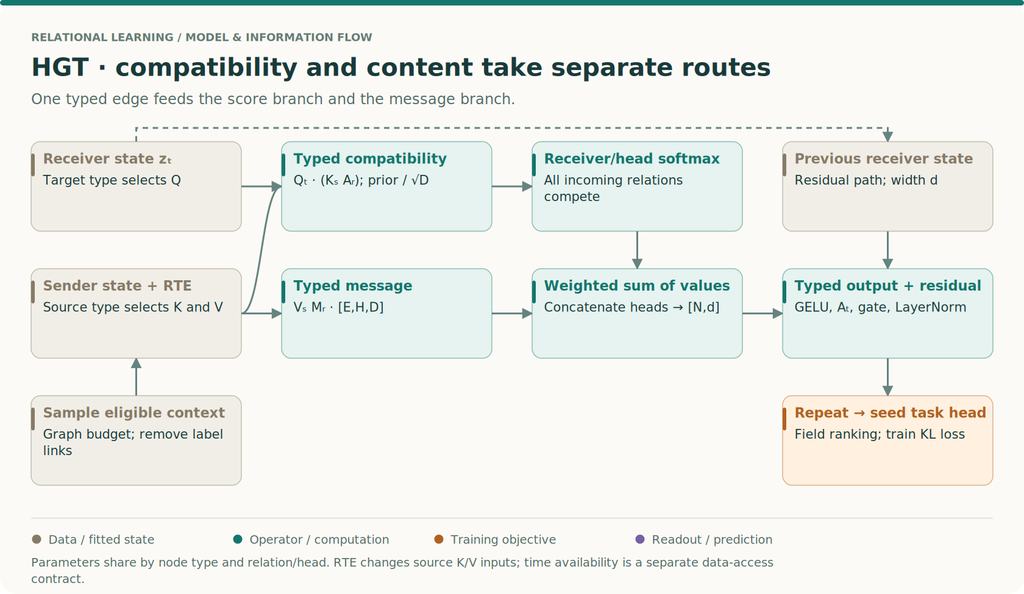

One typed edge feeds the score branch and the message branch. Parameters share by node type and relation/head. RTE changes source K/V inputs; time availability is a separate data-access contract.

### Read the forks before the arrows merge

One edge does two jobs. Its key meets the receiver's query to produce a scalar compatibility score per head. Its value becomes a vector message per head. Relation matrices affect both jobs through separate parameter banks. Multiplying a message by an attention weight joins the branches; the scalar alone is not the message. Read [HGT §3.2–3.4](https://arxiv.org/html/2003.01332v1) with that separation in view.

Suppose two edges receive weights .9 and .1, but their scalar message coordinates are 1 and 20. Their contributions are .9 and 2. The edge with smaller attention supplies the larger positive coordinate. If the second value were −20, its contribution would oppose the first. Thus a displayed attention heatmap is not a decomposition of predictive importance. Output projection, residual mixing and later layers further change the result.

### Trace the parameter-sharing decision

Consider `(author,writes,paper)` and `(author,reviews,paper)`. Both use the author-type key/value projections and paper-type query projection. Different relation transforms still distinguish writing from reviewing. Now consider `(paper,cites,paper)`: the target query map is still the paper map, while the sender key/value map changes to the paper map. Write down those shared and changed pieces before counting parameters.

This factorization is a modeling bias: it lets multiple connections reuse type-level transformations. It is not permission to merge distinct foreign-key roles into an ambiguous relation name. The data representation must preserve the role before a learned layer can use it. L096 will make that identity contract executable.

### Cross-relation normalization is part of the architecture

At one receiver/head, collect every eligible incoming score and take one softmax. A new candidate can change every existing normalized weight even if their raw scores remain fixed. With scores `[0,ln 2]`, weights are `[1/3,2/3]`. Add an edge with score zero and they become `[1/4,1/2,1/4]`. If all three message values equal 5, the aggregate stays 5. Changing weights therefore need not change the message; changing the message need not identify which score caused it.

This observation connects sampling to modeling. Dropping one competitor changes a softmax denominator. Finite-fanout attention is not merely a cheaper way to write the same full-neighborhood formula. L098 isolates this difference before L100 integrates it into the comparison.

### Finish the layer, then choose the task

The released operator concatenates head outputs, transforms them, and blends the result with the previous state. With a scalar teaching gate of .75, old state 2 and candidate 6, the mixture before normalization is 5. Omitting the residual would give 6. Equal attention coefficients cannot establish equality of two layers that have different value maps or residual paths. The [pinned release](https://github.com/acbull/pyHGT/blob/85eaccd482bc1d1af56c2de297b6e3a88b96d5cd/OAG/pyHGT/conv.py) is essential here because its gated update differs from the paper's printed additive residual.

The output task determines the final head and loss. The paper-field reconstruction predicts a distribution over fields; the later course ACM comparison predicts one conference class. Sharing an HGT operator does not make these the same experiment.

**Try first: does relative time make future context safe?**

No. A numerical age encoding changes the representation of whatever data reached the layer. It cannot establish that those data existed at prediction time. Audit graph membership, edge times, feature histories and target-link removal separately. Even an age of zero need not produce a zero encoding.

**Reading checkpoint.** Annotate the source with four boundaries: graph access, sampling, learned message passing, and supervised targets. Then inspect the existing paper/release deviations below. Bring to L094 a description of the computation, not a claim that “Transformer” implies a stronger model.

## 1 · Why go beyond HAN?

**Start with the limitation.** Suppose the prediction target is a paper's research fields. Authors, venues, institutions and other papers can all help. HAN asks you to define useful routes such as paper–author–paper before fitting the model. A route you omit cannot acquire a HAN branch merely because training would find it useful.

**Change the unit of computation.** HGT starts with one-hop typed edges. One layer can bring an author's information to a paper. A second layer can bring that author's institution information along the same route. Stacking layers composes routes without constructing a separate adjacency matrix for every meta-path. This is the connection between [paper Figure 1 and §3.4](https://arxiv.org/html/2003.01332v1#S3.SS4).

A **node type** describes the kind of entity: paper or author. A **relation type** describes an edge: cites or writes. A **meta-relation** is the triple *(source node type, relation type, target node type)*. It is one step. A **meta-path** is a sequence of such steps.

> **In plain terms.** Let authors and papers use different ways to describe themselves, but make their resulting messages comparable at the receiving paper.

HGT does not explicitly choose one discrete best path. A stack mixes many walks, with nonlinearities and residual paths between layers. Products of displayed attention weights are useful traces, not calibrated causal explanations.

## 2 · Model architecture

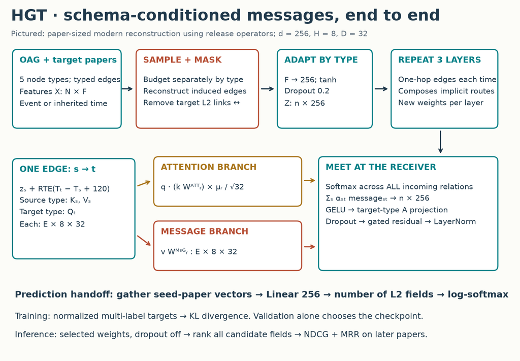

End-to-end HGT reconstruction: typed inputs, sampled graph, separate attention/message branches, residual update and field-ranking handoff.

**Read the picture from inputs to prediction.** The graph supplies node features, node types, directed relation IDs and times. An input adapter maps each type's features to a common hidden width. This makes the tensor dimensions compatible without forcing every type to share the same projection.

Inside a layer, the same edge feeds **two branches**. The attention branch asks how strongly the target should listen. The message branch decides what numerical vector arrives. Their outputs meet in a weighted sum at the target. A target-type projection and residual update produce the next representation.

After the final layer, gather the seed papers—the papers selected for supervision in this batch. A linear classifier produces one score for each candidate level-2 field. A paper can have several valid fields. The released trainer normalizes its field indicators to sum to one and uses KL divergence against log-softmax predictions. At inference, turn those scores into a field ranking.

**Shapes to keep on paper:** input `X[n,F]`; adapted states `Z[n,d]`; queries, keys and values per edge `[E,H,D]`, where `D=d/H`; attention weights `[E,H]`; messages `[E,H,D]`; output states `[n,d]`; supervised predictions `[B,C]` for B seed papers and C candidate fields.

The pictured reconstruction uses the paper's `d=256`, `H=8`, three layers. The release defaults to width 400 and four layers. The small NN teaching comparison uses width 32 and two layers. These are explicitly different experimental settings.

## 3 · One edge, three kinds of sharing

### First: project by node type

A **query** describes what a receiver is looking for. A **key** describes what a sender offers. A **value** is the content to aggregate.

For source `s`, target `t`, head `i`:

```
q = Q[target_type](z_t)[head i]   # D coordinates
k = K[source_type](z_s)[head i]   # D coordinates
v = V[source_type](z_s)[head i]   # D coordinates
```

The Q, K and V maps have separate parameters. Two author→paper relations can share the author's K/V maps and the paper's Q map. Changing writes-first to writes-last still changes the relation's matrices. A relation-specific full transform for every triple would forgo this sharing.

### Second: transform by relation

The relation has an **attention matrix** and a **message matrix**, both `D×D` per head. They serve different purposes. The first modifies compatibility; the second transforms content. The release also learns one scalar prior per relation/head.

```
score(s,r,t,i) = dot(q, k @ W_attention[r,i]) * prior[r,i] / sqrt(D)
message(s,r,t,i) = v @ W_message[r,i]
```

[Paper Eqs. 3–4](https://arxiv.org/html/2003.01332v1#S3.SS2) motivate this factorization. **Read the notation carefully:** the paper prints `sqrt(d)` and a meta-relation prior; the release uses `sqrt(D)` and relation/head priors. Our released-operator lane follows the code. Relation names in the OAG graph identify typed connections; the loader rejects ambiguous reused names rather than silently overwriting their meaning.

### Third: normalize at the target

> **In plain terms.** An author and a cited paper competing to inform the same target must appear in the same denominator.

For each receiver/head, softmax spans **all incoming edges**, across relation types. It does not span nodes elsewhere in the batch, and it is not applied separately to each relation. This is the live `receiver_softmax` task in the lab.

**Predict first:** should author and citation edges share a denominator? Commit before reading the example.

**Worked example.** One head has `D=2`. After projection, the receiving paper's query is `[1,0]`. An author has key `[0,1]` and value `[2,0]`. A cited paper has key `[sqrt(2)·ln(2),0]` and value `[6,0]`. With identity relation matrices and priors of one, their scores are `0` and `ln(2)`.

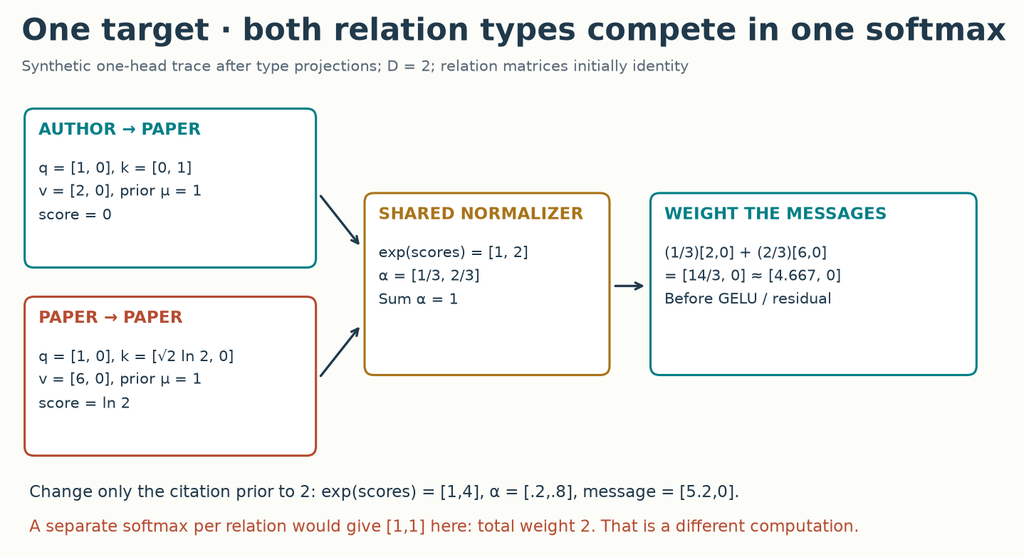

Synthetic worked trace: joint weights1/3 and2/3 produce14/3. Doubling the citation logit prior produces5.2.

Their unnormalized weights are `1` and `2`. Softmax gives `1/3` and `2/3`. The aggregate is `[14/3,0] ≈ [4.667,0]`. This is the value **before** the output nonlinearity, type projection, gate and normalization.

Now double only the citation prior. It multiplies the logit, so `exp(2 ln2)=4`. The weights become `.2` and `.8`; the first output coordinate becomes `5.2`. A prior is not an additive probability or a multiplier applied after softmax.

### A larger prior can make an edge receive less attention

The name “prior” can suggest a probability, but the [released parameter](https://github.com/acbull/pyHGT/blob/85eaccd482bc1d1af56c2de297b6e3a88b96d5cd/OAG/pyHGT/conv.py) is an unconstrained learned scalar. It multiplies a score before the joint softmax. Its effect depends on that score's sign.

Keep two edges at one receiver. The first has base score `−ln 2` and scalar message 8; the second has score 0 and message 2. Change only the first edge's prior:

| Prior | First weight | Aggregate |
| --- | --- | --- |
| −1 | 2/3 | 6 |
| 0 | 1/2 | 5 |
| 1 | 1/3 | 4 |
| 2 | 1/5 | 3.2 |

For prior 2, the first exponential becomes `exp(−2 ln 2)=1/4`, so its weight is `(1/4)/(1/4+1)=1/5`. Raising the prior reduced its contribution. Negative priors are allowed by the release and can reverse a score's sign.

**Does prior 0 remove the edge?** No: it makes its logit zero, whose exponential is 1. The edge still competes and sends its value; this example returns 5. Actually removing it would leave only message 2. To ablate a relation, remove or mask its edges under a declared protocol; setting its prior to zero is a different intervention.

**Intervene:** set the citation prior to0,1,2. Compute weights and the first output coordinate. CHECK: outputs4,14/3,5.2.

**Stop and diagnose.** If you normalize separately by relation in this two-edge example, each relation receives weight one. Their sum is two, and the message is `[8,0]`. You have changed the model, even though each local softmax looks correct.

### Finish the layer

Concatenate the head outputs, apply GELU, and project with the receiver's type-specific A map. The release mixes this candidate with the old state using `a=sigmoid(skip[type])`, then optionally applies LayerNorm:

```
candidate = dropout(A[target_type](GELU(aggregate)))
new_state = LayerNorm(a * candidate + (1-a) * old_state)
```

The [paper's Eq. 5](https://arxiv.org/html/2003.01332v1#S3.SS4) instead writes a simple additive residual. A gate initialized from `skip=1` starts at about `.731`, not one. Copying only the attention equation does not reproduce the released layer.

## 4 · Relative time changes what the sender says

An author or venue may not have one natural timestamp. The sampler can assign it the time of the paper that brought it into the computation. A paper has an event time: its publication year. A **relative time gap** is the receiving node's assigned time minus the sending node's assigned time.

**Worked example.** A 2012 source paper contributes to a 2015 target with gap3, and to a 2018 target with gap6. Its original features are identical in both contexts. Its augmented source representation need not be.

The release uses a sinusoidal table initialized at integer indices 0…239. The data conversion adds 120 to the signed gap. A learned linear map transforms the selected row; its output is added to the source state **before both K and V**. The target query does not receive this source-side addition.

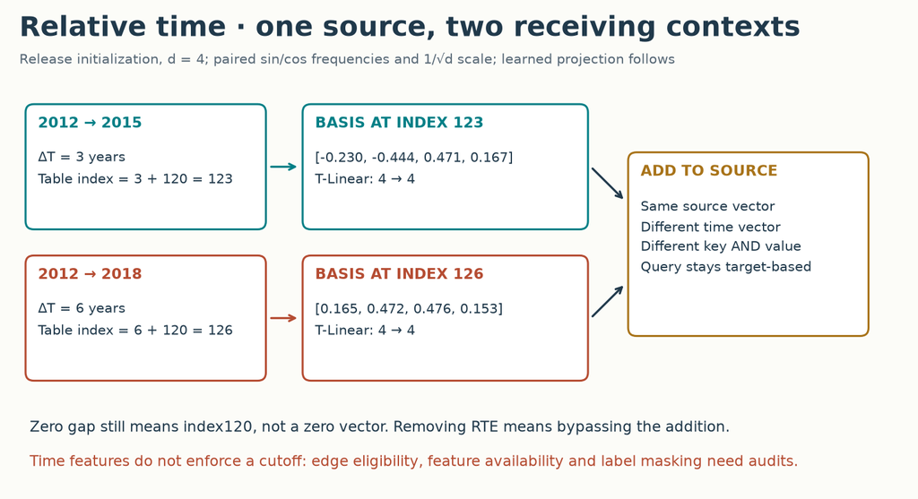

Same2012 source, different receiving contexts: release table indices123 and126 change source keys and values.

For the release initialization, even/odd coordinates share a frequency, and values are scaled by `1/sqrt(d)`. The printed [paper Eqs. 6–9](https://arxiv.org/html/2003.01332v1#S3.SS5) use distinct even/odd exponents and no such scale or index shift. The lab's `temporal_basis` supports both printed and released formulas so you can identify the difference.

**A subtle source bug.** Setting `embedding.requires_grad=False` on the module does not freeze its weight parameter. The release does this, leaving the table trainable. The reconstruction preserves that observed behavior and verifies its gradients. A fixed-table alternative would be a distinct, declared intervention.

**Prediction:** does setting every gap to zero remove time information? No. Zero gap maps to table row 120, and the learned linear map can produce a nonzero vector. The no-RTE arm bypasses the addition entirely.

> **Scope check.** RTE encodes time; it does not enforce causal data access. You must separately control edge availability, feature construction, label links and prediction cutoffs. The old release limits candidate expansion by time but reconstructs induced edges without checking their timestamps again. Its provided features also need a separate point-in-time provenance audit before use in a prospective database prediction task.

This distinction prepares you for temporal graph methods later in Year 3 and the time-aware database representations in Year 4.

## 5 · HGSampling makes the graph manageable

A **seed node** is a prediction target selected for the batch. A **budget** stores candidate neighbors and their accumulated sampling scores. Heterogeneous Graph Sampling maintains a separate budget for each node type.

**Why separate budgets?** If papers vastly outnumber institutions, globally sampling candidates can nearly erase the institution type. Per-type quotas keep the computation from being dominated simply by population size. They do not guarantee identical counts when a type has too few candidates.

**Worked example.** Selected paper p0 has authors a and b; selected paper p1 has authors b and c. Each paper contributes half a unit to each of its two authors. Budgets become `[.5,1,.5]`. Squaring and normalizing gives `[1/6,2/3,1/6]`.

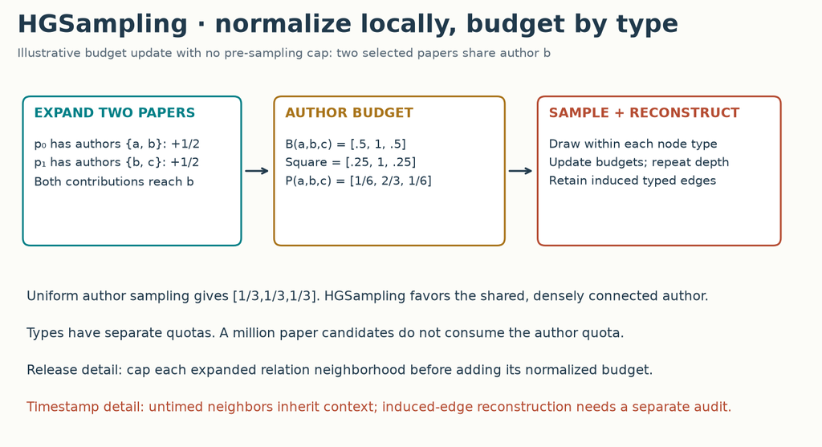

Illustrative per-type budget [.5,1,.5] becomes sampling probabilities [1/6,2/3,1/6].

Author b is favored because it connects to both sampled papers. After drawing nodes without replacement inside each type, add their neighbors to the budgets, repeat to the requested depth, and reconstruct the induced graph among selected nodes. These are [paper Algorithms 1–2](https://arxiv.org/html/2003.01332v1#S4.SS1).

The release first caps the neighbors considered in each expansion. It can also overwrite the inherited time of a candidate reached from several contexts. Our source-parity check compares actual sampled IDs, features, typed edges and relative times, not just their counts.

**Do not confuse two depths.** Sampling depth determines the available subgraph. Neural layer count determines how many message-passing steps the model performs inside it. The release samples to depth 6 but uses four neural layers by default.

### Remove the answer from the graph

To predict a seed paper's L2 fields, remove both its paper→L2-field links and their reverse links from the sampled graph. Leaving the reverse relation preserves a route that directly reveals the answer. Other context nodes can still carry observed field relations under this released task.

The lab asserts both directions are absent for seed papers. It also records the split boundaries: training years before 2015; validation 2015–2016 inclusive; test years after 2016. The paper's prose overlaps at 2016; the code resolves the boundary explicitly. These splits do not by themselves prove that every precomputed feature was available at prediction time.

## 6 · Compare models without comparing different graphs

The lab uses the **released NN subset of OAG**, containing 66,211 nodes across five types. Its L2 prediction task has 8,489 training papers, 3,439 validation papers and 6,983 test papers; rankings span 4,782 candidate fields.

Three arms share source data, features, splits, seed targets, sampled subgraphs, optimizer, training budget and evaluation queries: HGT, a visible relation-mean R-GCN comparison, and HGT without RTE. All use the same width 32/two-layer budget. Equal width does not mean equal parameter counts; the table reports them. This R-GCN arm is a course comparison, not the unavailable original Table 2 baseline implementation.

Each run fits40 updates across 10 epochs. Validation NDCG alone selects the saved weights. Ten test batches of 32 papers are sampled afterwards. Batches may overlap; they are not ten independent datasets. Three model seeds measure run variability on this one graph.

**Before looking at the results:** could restricting the data to neural-network papers make one target field nearly universal? What would a classifier that always ranks that field first achieve under MRR?

**Author-reference evidence, not your current kernel output.** Nine complete neural fits on the NN graph. Mean ± sample SD across3 seeds.

| Arm | Trainable parameters | NN NDCG | NN MRR |
| --- | --- | --- | --- |
| HGT | 422,792 | 0.4143 ± 0.0083 | 1.0000 ± 0.0000 |
| R-GCN | 412,654 | 0.4170 ± 0.0048 | 0.9976 ± 0.0023 |
| HGT without RTE | 405,320 | 0.4221 ± 0.0067 | 1.0000 ± 0.0000 |
| Train-frequency baseline | 0 | 0.4880 ± 0.0075 | 1.0000 ± 0.0000 |

The most frequent training field is **Artificial neural network**, present in every training and test paper in this NN subset. A training-only frequency ranking reaches MRR 1.0 and higher NDCG than these small neural runs. That diagnosis matters more than declaring a winner among nearly tied neural arms. The baseline SD only reflects sampled queries; it has no model-initialization variability.

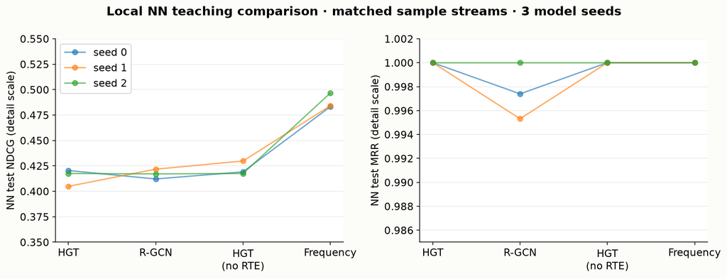

Measured NN teaching comparison over3 model seeds; one dataset, paired query streams, not CS paper reproduction.

**Metric diagnosis.** MRR measures the reciprocal rank of the first relevant field. It can saturate while many other correct fields rank poorly. NDCG reflects more of the ranking, but you must state its exact discount. The release uses DCG “method0”: ranks1 and2 both have denominator1; rank3 has denominator `log2(3)`. This differs from the common `log2(rank+1)` convention. The independent audit recomputes metrics from each query's relevant ranks.

> **Scope check.** These are descriptive NN results. Neither close scores nor a winning arm establish a general HGT ranking. This lesson has one graph, one small configuration and only three model seeds. No multi-dataset statistical superiority claim is made.

## 7 · Full reproduction: name the claim before running

The named target is **Table 2, CS Paper–Field L2, HGT with heterogeneity and RTE**: NDCG `.403 ± .041`, MRR `.439 ± .078`, reported over five trainings. See [the original table and settings](https://arxiv.org/html/2003.01332v1#S5). Those are cited paper results, not our measurements.

The CS and NN downloads are hash-pinned independently. CS bytes were acquired; identity to the exact paper-era snapshot is not established. The linked CS file was modified after publication. NN cannot substitute for CS because its selection changes the target distribution.

| Protocol element | Paper statement | Pinned release / reconstruction |
| --- | --- | --- |
| Model width / layers | 256 / 3 | Default release400 /4; `paper` preset uses256 /3 |
| Heads / schedule | 8 /200 epochs | Preserved;32 batches ×2 reuse passes each epoch |
| Checkpoint choice | Lowest validation loss | Release highest validation NDCG; presets keep these separate |
| Attention scale | Printed sqrt(d) | Released sqrt(d/head count) |
| Residual update | Additive | Learned type gate and optional LayerNorm |
| Temporal basis | Fixed sinusoids as printed | Shifted, scaled, paired frequencies; table actually trainable |
| Labels / objective | Multiple field labels | Normalize indicators; batch-mean KL divergence |
| Sampling | HGSampling | Released capped-neighbor version, serial declared streams |
| Optimizer | AdamW + cosine annealing | Explicit defaults; released step counter begins at1500 |
| Evaluation | NDCG /MRR, five trainings | Released DCG convention; ten sampled test batches per fit |
| Feature provenance | XLNet /metapath2vec features | Supplied release features; raw feature extraction not rerun |
| Historical randomness | Original seeds unavailable | Five declared fresh seeds; no historical RNG identity claim |

**Source chronology matters.** We also archive the publication-era2020-04-16 code. It has triplet priors, no LayerNorm, different residual dropout and a different2d temporal table. The tested modern operator is not identical to that historical implementation. The exact revision behind Table 2 is unknown; the historical runtime replay remains unrun.

**Why two large presets?** `release` follows the published code defaults. `paper` changes the dimensions and selection rule explicitly stated in the paper while retaining the audited released operators. It is a reconstruction with remaining deviations, not a switch that makes those discrepancies disappear.

**Executed:** layer output/attention/gradient parity; two source-sampler comparisons; nine small NN fits; training-frequency baseline; one paper-width update on NN. **Not executed:** full CS five-run target, historical runtime and full-paper suite. CS loading exceeded a declared 10 GiB virtual-memory guard; Modal rejected the GPU invocation because a payment method was required. Full-paper parity remains **NOT_ESTABLISHED**, historical comparison **INCOMPARABLE**. These are actual blockers, not successful reproduction results.

The complete loader, sampler, model, objective, optimizer, checkpoint selection and evaluation are visible in the notebook. The CLI and GPU entrypoint use the same canonical implementation. The [reproduction contract](https://avistian.github.io/relational/labs/l093-reproduction.md) contains exact commands, hashes, measured coverage and the remaining full-paper work.

## 8 · Lab: three live tasks and a defensible report

[Student notebook](https://avistian.github.io/relational/labs/0093-hgt.ipynb) · [Prepared notebook view](https://avistian.github.io/relational/labs/html/0093-hgt.html) · [Teacher solution](https://avistian.github.io/relational/labs/solutions/0093-hgt.ipynb) · [Compact reference](https://avistian.github.io/relational/reference/hgt.html)

1. **TODO: receiver softmax.** Normalize each receiver/head over all incoming relations. CHECK distinguishes receiver grouping from global and per-relation normalization.
2. **TODO: relation attention and message.** Compute separate relation transforms for keys and values, and scale logits by head width. CHECK traces the `[4.667,0]` example and gradients.
3. **TODO: temporal basis.** Build the specified released and printed-paper bases. CHECK verifies origin, frequency, scale and distinct time responses. The initialized basis is called by the actual temporal module.

The rest is PROVIDED, but not hidden. Read the sampler and trainer in separate annotated cells. First run the one-update NN diagnostic. Then run the matched three-seed teaching comparison. The CS reproduction cell is gated off by default and documents its memory/GPU requirements.

**EXIT:** submit the checks, per-seed results, the training-frequency baseline, and a 150–250-word defense. Explain why normalization crosses relation types, where time enters, how label edges are masked, what the NN comparison establishes, and which reproduction gaps remain. Authored or pre-executed materials do not establish your mastery: **PENDING_WRITTEN_DEFENSE**.

**Teach back:** close the derivation and explain the full message, time and reproduction boundary in your own words.

## Carry this forward

R-GCN taught relation-specific transforms. HAN taught explicitly constructed semantic routes. HGT combines node-type projections with relation transforms and composes routes through depth. The next curriculum lesson, 94, organizes these methods into a heterogeneous-information-network taxonomy. Later, RelGT will revisit type, structure and time inside a database-oriented Transformer.

Tomorrow, retrieve the softmax denominator without looking. In three days, derive why zeroing the time gap differs from disabling RTE. Ask the teacher to challenge any unclear equation, sampler step or reproduction claim before moving on.

## PROVIDED · Source and data provenance

The manifest pins both NN and CS downloads. Download hashes establish byte identity to our retrieved release, not to the unpublished historical experiment state.

```python
SOURCE_MANIFEST={'source_revision': '85eaccd482bc1d1af56c2de297b6e3a88b96d5cd', 'source_url': 'https://github.com/acbull/pyHGT', 'paper': 'https://arxiv.org/html/2003.01332v1', 'files': {'README.md': '022913cedc49a9cf133ecddc004f65ddf3fe2a78f89c0b376af7cfa5ebf7b173', 'LICENSE': '54572f6f2d0175ca56f42a023739f6560dd0ad79ae4ee578553bddd87862c015', 'OAG/train_author_disambiguation.py': '5925deefb9bdc38a83bdf88f9232cc05ceda7ae867789156346fb11930c2ee58', 'OAG/train_paper_venue.py': '34f03e443bf971d65899758688f656b19e08e2a745f9fa9553c905d22aed9b77', 'OAG/preprocess_OAG.py': '3203b860c2515a80a7828540c1a4f0cae8229694280de6c04fadb0b66eb879f1', 'OAG/train_paper_field.py': 'fcae7df3178f2c795e7a444cc78cd837c7a8865959c9e0b7cf96976d9fc8b76b', 'OAG/pyHGT/utils.py': '218598d47381778d23f02a54033436503c15d1cc5963816ff3114eb5ca95d97a', 'OAG/pyHGT/__init__.py': 'e3b0c44298fc1c149afbf4c8996fb92427ae41e4649b934ca495991b7852b855', 'OAG/pyHGT/model.py': 'a96faab8646e517636f6229df5ed147879cff6ce388d84cf2b5ba64628765e26', 'OAG/pyHGT/conv.py': '14ace211323d9d163d4edbc5203aa2bd59c31681af0ca39dd9ff9a5bbbf856b0', 'OAG/pyHGT/data.py': '87850d34d529e0b4b7eb5f4b621fcafb60785a4992e750e10988d9e2ba3268f5', 'publication-2020/utils.py': '218598d47381778d23f02a54033436503c15d1cc5963816ff3114eb5ca95d97a', 'publication-2020/requirements.txt': '5204bcce55c6e22fca7a70eac3d5aebc7a13493db0e6d9f3ea9d0ea4a6dc6e8d', 'publication-2020/model.py': 'a5acc2f5e949ba1544524ac4b89fd1808433c4505681dfcca4441b288ac90caf', 'publication-2020/conv.py': 'f5111cf48edb68278154126291326020f216857252f80168b5b5568b3b440e21', 'publication-2020/data.py': '963463e9ae9dea65d591a0d0d1d89a822c10ea6a4c56927ac98418c965d23216', 'publication-2020/README.md': '022fcc520f4e0d4fe525b072d038d93220bf87da1d03085253a162d42d3e2492', 'publication-2020/LICENSE': '54572f6f2d0175ca56f42a023739f6560dd0ad79ae4ee578553bddd87862c015', 'publication-2020/train_paper_field.py': 'e45499cc20ad622444f42eb7d6f5557618e599b7ecc1cf79c0bc5becf161383c'}, 'target': {'table': 2, 'dataset': 'CS', 'task': 'Paper-Field L2', 'ndcg': 0.403, 'mrr': 0.439, 'runs': 5}, 'data_links': {'CS': '1RYrGoBAIVMuYnFxznBgsmhxRLZTWtsM9', 'NN': '1U8rxYcBljfey6t04qrKmtfvdO8x8wJyu'}, 'nn_data': {'filename': 'graph_NN.pk', 'bytes': 656262985, 'sha256': '7e0e7b997c427af479148f1d9af419878648b0624b4d3f9f1790bc3625cd7e61', 'url': 'https://drive.usercontent.google.com/download?id=1U8rxYcBljfey6t04qrKmtfvdO8x8wJyu&export=download&confirm=t'}, 'cs_data': {'filename': 'graph_CS.pk', 'bytes': 8606617611, 'sha256': 'bf054d93f45d385691f89902e7a021c53328c2ffefe50eb4d91c9dc51d05877f', 'identity_to_paper_snapshot': 'NOT_ESTABLISHED', 'folder_modified_date': '2020-11-28'}, 'publication_source_revision': 'fd4a244db8efc72410537f3effec3b0c432892f7', 'publication_source_note': '2020-04-16 source; prior triplets, no LayerNorm, residual dropout and different 2d temporal table. Exact table-producing revision unknown.'}
```

```python
"""L093: visible HGT release port and OAG Paper-Field L2 training.
Reference: acbull/pyHGT revision85eaccd, MIT (archived in labs/sources/hgt-l093).
Paper Table2 parity is NOT_ESTABLISHED; see l093-reproduction.md.
"""
```

```python
from pathlib import Path
```

```python
from collections import defaultdict
```

```python
import copy,hashlib,json,math,platform,time,urllib.request
```

```python
import numpy as np
```

```python
import pandas as pd
```

```python
import dill
```

```python
import torch
```

```python
from torch import nn
```

```python
from torch.nn import functional as F
```

### TODO · receiver_softmax

Group by receiver and head. Normalize across every incoming relation. Preserve finite outputs and gradients; isolated nodes receive no edges.

```python
def receiver_softmax(logits, target, nodes):
    raise NotImplementedError("Implement receiver_softmax before running CHECK")
```

```python
# CHECK
z=torch.tensor([[0.],[math.log(2)],[0.]],requires_grad=True)
d=torch.tensor([2,2,3]);w=receiver_softmax(z,d,5)
torch.testing.assert_close(w,torch.tensor([[1/3],[2/3],[1.]]))
(w*torch.tensor([[2.],[6.],[1.]])).sum().backward();assert z.grad.abs().sum()>0
print('PASS: receivers are independent; different relations compete; gradients flow')
```

### TODO · relation_heads

Apply different relation matrices to keys and values. Compute scaled compatibility with the query and prior. Return edge logits and messages.

```python
def relation_heads(q,k,v,attention_matrix,message_matrix,prior):
    raise NotImplementedError("Implement relation_heads before running CHECK")
```

```python
# CHECK
q=torch.tensor([[[1.,0.]],[[1.,0.]]]);k=torch.tensor([[[0.,1.]],[[math.sqrt(2)*math.log(2),0.]]],requires_grad=True)
v=torch.tensor([[[2.,0.]],[[6.,0.]]]);w=torch.eye(2).reshape(1,1,2,2).expand(2,1,2,2);p=torch.ones(2,1)
s,m=relation_heads(q,k,v,w,w,p);weights=receiver_softmax(s,torch.tensor([0,0]),1)
value=(weights[:,:,None]*m).sum(0)
torch.testing.assert_close(value,torch.tensor([[14/3,0.]]));value.sum().backward();assert k.grad.abs().sum()>0
p[1]=2;s,m=relation_heads(q,k,v,w,w,p);changed=(receiver_softmax(s,torch.tensor([0,0]),1)[:,:,None]*m).sum(0)
torch.testing.assert_close(changed,torch.tensor([[5.2,0.]]))
print('PASS: relation transforms, head-width scaling and intervention')
```

### TODO · temporal_basis

Implement the stated release and printed-paper sinusoidal conventions. Preserve index order, even/odd coordinates and release scale.

```python
def temporal_basis(index,width,mode='release'):
    raise NotImplementedError("Implement temporal_basis before running CHECK")
```

```python
# CHECK
b=temporal_basis(torch.tensor([0.,1.]),4,'release');torch.testing.assert_close(b[0],torch.tensor([0.,.5,0.,.5]))
expected=torch.tensor([math.sin(1),math.cos(1),math.sin(.01),math.cos(.01)])/2
torch.testing.assert_close(b[1],expected)
p=temporal_basis(torch.tensor([1.]),4,'paper');torch.testing.assert_close(p[0],torch.tensor([math.sin(1),math.cos(.1),math.sin(.01),math.cos(.001)]))
assert not torch.allclose(temporal_basis(torch.tensor([123.]),4),temporal_basis(torch.tensor([126.]),4))
print('PASS: frequency, scale, and changed relative time')
```

### PROVIDED · RelativeTime

Paper§3.5 versus release. The table remains trainable to preserve the source bug. Index validation rejects unsupported gaps.

```python
class RelativeTime(nn.Module):
    def __init__(self,width):
        super().__init__()
        self.emb=nn.Embedding(240,width)
        with torch.no_grad():self.emb.weight.copy_(temporal_basis(torch.arange(240),width))
        # The release sets emb.requires_grad=False, not emb.weight.requires_grad=False.
        # Preserve its actual trainable table. This is a documented paper/release gap.
        self.lin=nn.Linear(width,width)
    def forward(self,x,index):
        if index.numel() and (index.min()<0 or index.max()>=240):
            raise ValueError('Release RTE index outside [0,239]; do not silently clip time gaps')
        return x+self.lin(self.emb(index))
```

### PROVIDED · HGTLayer

Paper§3, Figure2, Eqs3–5 versus the pinned OAG/pyHGT/conv.py. Trace source/target indexing, relation grouping, one joint softmax and the released gated update.

```python
class HGTLayer(nn.Module):
    def __init__(self,width,types,relations,heads,dropout=.2,use_norm=True,use_rte=True):
        super().__init__()
        if width%heads:raise ValueError('width must divide heads')
        self.width=width;self.heads=heads;self.d=width//heads;self.use_norm=use_norm;self.use_rte=use_rte
        self.k_linears=nn.ModuleList([nn.Linear(width,width) for _ in range(types)])
        self.q_linears=nn.ModuleList([nn.Linear(width,width) for _ in range(types)])
        self.v_linears=nn.ModuleList([nn.Linear(width,width) for _ in range(types)])
        self.a_linears=nn.ModuleList([nn.Linear(width,width) for _ in range(types)])
        self.norms=nn.ModuleList([nn.LayerNorm(width) for _ in range(types)] if use_norm else [])
        self.relation_pri=nn.Parameter(torch.ones(relations,heads))
        self.relation_att=nn.Parameter(torch.empty(relations,heads,self.d,self.d))
        self.relation_msg=nn.Parameter(torch.empty(relations,heads,self.d,self.d))
        self.skip=nn.Parameter(torch.ones(types));self.drop=nn.Dropout(dropout)
        if use_rte:self.emb=RelativeTime(width)
        # PyG glorot uses the last two dimensions, including on a 4D parameter.
        for w in (self.relation_att,self.relation_msg):nn.init.uniform_(w,-math.sqrt(3/self.d),math.sqrt(3/self.d))
        self.att=None
    def forward(self,x,node_type,edge_index,edge_type,edge_time):
        src,dst=edge_index;source=x[src];target=x[dst]
        if self.use_rte:source=self.emb(source,edge_time)
        q=torch.zeros_like(target);k=torch.zeros_like(source);v=torch.zeros_like(source)
        for t in range(len(self.k_linears)):
            sm=node_type[src]==t;tm=node_type[dst]==t
            k[sm]=self.k_linears[t](source[sm]);v[sm]=self.v_linears[t](source[sm]);q[tm]=self.q_linears[t](target[tm])
        q=q.reshape(-1,self.heads,self.d);k=k.reshape_as(q);v=v.reshape_as(q)
        # Relation grouping avoids an E×H×D×D allocation at paper width.
        scores=q.new_zeros((len(src),self.heads));messages=q.new_zeros(q.shape)
        for r in range(len(self.relation_pri)):
            mask=edge_type==r
            if mask.any():
                count=int(mask.sum())
                scores[mask],messages[mask]=relation_heads(q[mask],k[mask],v[mask],self.relation_att[r].expand(count,-1,-1,-1),self.relation_msg[r].expand(count,-1,-1,-1),self.relation_pri[r].expand(count,-1))
        self.att=receiver_softmax(scores,dst,len(x))
        aggregate=x.new_zeros((len(x),self.width))
        aggregate.index_add_(0,dst,(messages*self.att[:,:,None]).reshape(-1,self.width))
        aggregate=F.gelu(aggregate);out=torch.zeros_like(x)
        for t in range(len(self.a_linears)):
            mask=node_type==t;a=torch.sigmoid(self.skip[t])
            z=a*self.drop(self.a_linears[t](aggregate[mask]))+(1-a)*x[mask]
            out[mask]=self.norms[t](z) if self.use_norm else z
        return out
```

### PROVIDED · RGCNLayer

Teaching comparator: relation-specific means, sum across relations and one self transform. This is not the original Table 2 baseline implementation.

```python
class RGCNLayer(nn.Module):
    """Local comparison: per-relation mean, then sum relations and learned self path."""
    def __init__(self,width,relations):
        super().__init__();self.weights=nn.Parameter(torch.empty(relations-1,width,width));self.self_linear=nn.Linear(width,width)
        for w in self.weights:nn.init.xavier_uniform_(w)
    def forward(self,x,node_type,edge_index,edge_type,edge_time):
        src,dst=edge_index;out=self.self_linear(x)
        # Last relation is explicit self: use the learned self path exactly once.
        for r in range(len(self.weights)):
            m=edge_type==r
            if not m.any():continue
            degree=torch.bincount(dst[m],minlength=len(x)).clamp_min(1)
            out.index_add_(0,dst[m],(x[src[m]]@self.weights[r])/degree[dst[m],None])
        return F.relu(out)
```

### PROVIDED · HGTModel

Type adapters → repeated HGT layers → seed-paper gather → field log-probabilities. R-GCN uses the same adapters and classifier dimensions.

```python
class HGTModel(nn.Module):
    def __init__(self,inputs,width,types,relations,classes,heads=8,layers=3,dropout=.2,arm='hgt'):
        super().__init__();self.arm=arm
        self.adapters=nn.ModuleList([nn.Linear(inputs,width) for _ in range(types)])
        self.drop=nn.Dropout(dropout)
        self.layers=nn.ModuleList([HGTLayer(width,types,relations,heads,dropout,use_rte=arm!='hgt_no_rte') if arm!='rgcn' else RGCNLayer(width,relations) for _ in range(layers)])
        self.classifier=nn.Linear(width,classes)
    def forward(self,batch):
        x,nt,ei,er,et,targets,labels=batch
        z=x.new_zeros((len(x),self.classifier.in_features))
        for t,adapter in enumerate(self.adapters):
            mask=nt==t;z[mask]=torch.tanh(adapter(x[mask]))
        z=self.drop(z)
        for layer in self.layers:z=layer(z,nt,ei,er,et)
        return self.classifier(z[targets]).log_softmax(-1)
```

### PROVIDED · OAGGraph

Supporting code for the visible OAG implementation. Read the docstring and follow the data contract.

```python
class OAGGraph:
    """Compatibility container for the authors' released dill Graph object."""
    def get_types(self):return list(self.node_feature)
    def get_meta_graph(self):
        return [(t,s,r) for t,sv in self.edge_list.items() for s,rv in sv.items() for r in rv]
```

### PROVIDED · inert_legacy_code

Supporting code for the visible OAG implementation. Read the docstring and follow the data contract.

```python
def inert_legacy_code(*args):
    # Python3.7 bytecode in old defaultdict factories is not executed.
    return None
```

### PROVIDED · inert_legacy_function

Supporting code for the visible OAG implementation. Read the docstring and follow the data contract.

```python
def inert_legacy_function(*args):
    # The downloaded graph stores populated maps. Their historical lambda
    # factories are irrelevant to read-only sampling; missing keys must not be used.
    return dict
```

### PROVIDED · legacy_type

Supporting code for the visible OAG implementation. Read the docstring and follow the data contract.

```python
def legacy_type(name):
    return inert_legacy_code if name=='CodeType' else dill._dill._load_type(name)
```

### PROVIDED · OAGUnpickler

Compatibility for stored data only: old serialized defaultdict factories are not executed. Original Python3.7 loading identity remains untested.

```python
class OAGUnpickler(dill.Unpickler):
    def find_class(self,module,name):
        if name=='Graph' and module in ('pyHGT.data','GPT_GNN.data','data'):return OAGGraph
        if module=='pandas.core.indexes.numeric':return pd.Index
        if module in ('data','pyHGT.data','GPT_GNN.data') and name=='__dict__':return {}
        if module=='dill._dill' and name=='_load_type':return legacy_type
        if module=='dill._dill' and name=='_create_function':return inert_legacy_function
        return super().find_class(module,name)
```

### PROVIDED · file_sha256

Supporting code for the visible OAG implementation. Read the docstring and follow the data contract.

```python
def file_sha256(path):
    h=hashlib.sha256()
    with open(path,'rb') as f:
        for block in iter(lambda:f.read(8*1024*1024),b''):h.update(block)
    return h.hexdigest()
```

### PROVIDED · load_oag

Supporting code for the visible OAG implementation. Read the docstring and follow the data contract.

```python
def load_oag(path,expected_sha256):
    """Verify trusted release bytes before deserializing; missing hash fails closed."""
    if not expected_sha256 or file_sha256(path)!=expected_sha256:raise ValueError('OAG data SHA256 mismatch or missing expected hash')
    with open(path,'rb') as f:g=OAGUnpickler(f).load()
    assert 'paper' in g.node_feature and 'field' in g.node_feature
    return g
```

### PROVIDED · field_protocol

Released L2 candidates and non-overlapping year boundaries. Candidate order and declared shuffle are part of the experiment.

```python
def field_protocol(graph):
    """L2 task: candidate order and time boundaries follow train_paper_field.py."""
    candidates=list(graph.edge_list['field']['paper']['PF_in_L2'])
    pairs={'train':{},'valid':{},'test':{}}
    for paper,fields in graph.edge_list['paper']['field']['rev_PF_in_L2'].items():
        for field,year in fields.items():
            if year is None:raise ValueError('Untimed target label requires an explicit protocol decision')
            split='train' if year<2015 else ('valid' if year<=2016 else 'test')
            if paper not in pairs[split]:pairs[split][paper]=[[],year]
            pairs[split][paper][0].append(field)
    # Release shuffles complete train/validation dictionaries with seed43.
    rng=np.random.RandomState(43)
    for split in ('train','valid'):
        ids=rng.choice(list(pairs[split]),len(pairs[split]),replace=False)
        pairs[split]={int(i):pairs[split][i] for i in ids}
    ids=[set(p) for p in pairs.values()]
    assert not any(ids[i]&ids[j] for i in range(3) for j in range(i+1,3))
    return candidates,pairs
```

### PROVIDED · sample_oag

Paper Algorithms1–2 plus released capped expansion, inherited time, induced edges and bidirectional target-label masking. Read the entire function before training.

```python
def sample_oag(graph,pairs,candidates,seed,batch_size=256,depth=6,width=128,cutoff=2014):
    """Release HGSampling, serial RNG, degree budget, time inheritance and induced edges.
    Adapted from MIT pyHGT data.py. Cutoff filters candidate expansion; the release
    does NOT re-filter induced edge timestamps. This is disclosed, not silently fixed.
    """
    rng=np.random.RandomState(seed)
    ids=rng.choice(list(pairs),batch_size,replace=False)
    selected=defaultdict(dict);budget=defaultdict(dict)
    def add_budget(t,target,year):
        for s,relations in graph.edge_list[t].items():
            for r,adj in relations.items():
                if r=='self' or target not in adj:continue
                neighbors=adj[target]
                choices=list(neighbors) if len(neighbors)<width else rng.choice(list(neighbors),width,replace=False)
                for node in choices:
                    when=neighbors[node] if neighbors[node] is not None else year
                    if when>cutoff or node in selected[s]:continue
                    old=budget[s].get(node,[0.,0])
                    budget[s][node]=[old[0]+1/len(choices),when]
    for i in ids:selected['paper'][int(i)]=[len(selected['paper']),pairs[i][1]]
    for i in ids:add_budget('paper',i,pairs[i][1])
    for _ in range(depth):
        for t in list(budget):
            keys=np.array(list(budget[t]));n=len(keys)
            if n==0:continue
            if width>n:chosen=np.arange(n)
            else:
                probability=np.array([v[0] for v in budget[t].values()])**2;probability/=probability.sum()
                chosen=rng.choice(n,width,p=probability,replace=False)
            nodes=keys[chosen]
            for node in nodes:selected[t][node]=[len(selected[t]),budget[t][node][1]]
            for node in nodes:
                add_budget(t,node,budget[t][node][1]);budget[t].pop(node)
    types=graph.get_types();offset={};features=[];node_types=[];times=[];node_ids={};total=0
    for t_id,t in enumerate(types):
        offset[t]=total;keys=list(selected[t]);node_ids[t]=keys;total+=len(keys)
        if not keys:continue
        frame=graph.node_feature[t].loc[keys]
        emb=np.asarray(list(frame['node_emb'].to_numpy()),dtype=float) if 'node_emb' in frame else np.zeros((len(keys),400))
        feat=np.concatenate([emb,np.asarray(list(frame['emb'].to_numpy()),dtype=float),np.log10(frame['citation'].to_numpy(dtype=float)[:,None]+.01)],axis=1)
        features.append(feat);node_types.extend([t_id]*len(keys));times.extend([v[1] for v in selected[t].values()])
    # Same relation-name indexing as the release; names must identify unique meta edges.
    meta=graph.get_meta_graph();relation={r:i for i,(_,_,r) in enumerate(meta)};relation['self']=len(relation)
    if len(relation)!=len(meta)+1:raise ValueError('Repeated relation name: audit meta-relation indexing before execution')
    edges=[];rels=[]
    for t in types:
        for node,(local,_) in selected[t].items():edges.append([offset[t]+local,offset[t]+local]);rels.append(relation['self'])
    for t,srcs in graph.edge_list.items():
        for s,relations in srcs.items():
            for r,adj in relations.items():
                for target,(tid,_) in selected[t].items():
                    if target not in adj:continue
                    for source in adj[target]:
                        if source not in selected[s]:continue
                        sid=selected[s][source][0]
                        # Remove the task label edge in BOTH directions for all seed papers.
                        if r=='rev_PF_in_L2' and t=='paper' and tid<batch_size:continue
                        if r=='PF_in_L2' and s=='paper' and sid<batch_size:continue
                        edges.append([offset[s]+sid,offset[t]+tid]);rels.append(relation[r])
    ei=torch.tensor(edges,dtype=torch.long).T;ts=torch.tensor(times)
    et=(ts[ei[1]]-ts[ei[0]]+120).long()
    y=np.zeros((len(ids),len(candidates)),dtype=np.float32);ci={v:i for i,v in enumerate(candidates)}
    for row,node in enumerate(ids):
        for label in pairs[node][0]:y[row,ci[label]]=1
    y/=y.sum(1,keepdims=True)
    batch=(torch.tensor(np.concatenate(features),dtype=torch.float32),torch.tensor(node_types),ei,torch.tensor(rels),et,torch.arange(batch_size)+offset['paper'],torch.from_numpy(y))
    audit={'seed':int(seed),'paper_ids':ids.tolist(),'nodes':total,'edges':len(edges),'node_ids':{k:[int(i) for i in v] for k,v in node_ids.items()},'relation_ids':relation}
    return batch,audit
```

### PROVIDED · ranking_metrics

Released DCG method0, not the commonly assumed rank+1 denominator.

```python
def ranking_metrics(log_prob,labels):
    """Release DCG method0: ranks1 AND2 have denominator1; MRR first relevant."""
    order=log_prob.argsort(descending=True,dim=1)
    relevance=labels.gather(1,order)
    discount=torch.ones(labels.shape[1],device=labels.device)
    if len(discount)>1:discount[1:]=torch.log2(torch.arange(2,len(discount)+1,device=labels.device))
    dcg=(relevance/discount).sum(1);ideal=(labels.sort(descending=True,dim=1).values/discount).sum(1)
    ndcg=dcg/ideal.clamp_min(1e-12)
    relevant=relevance>0;first=relevant.to(torch.int64).argmax(1)+1
    mrr=torch.where(relevant.any(1),1/first.float(),0.)
    return ndcg,mrr
```

### PROVIDED · protocol_config

Supporting code for the visible OAG implementation. Read the docstring and follow the data contract.

```python
def protocol_config(preset):
    common={'heads':8,'dropout':.2,'lr':.001,'weight_decay':.01,'clip':.25,'selection':'valid_ndcg','device':'cpu'}
    if preset=='paper':common.update(width=256,layers=3,epochs=200,batches=32,repeat=2,batch_size=256,depth=6,sample_width=128,test_batches=10,selection='valid_loss')
    elif preset=='release':common.update(width=400,layers=4,epochs=200,batches=32,repeat=2,batch_size=256,depth=6,sample_width=128,test_batches=10)
    elif preset=='teaching':common.update(width=32,layers=2,epochs=10,batches=4,repeat=1,batch_size=32,depth=2,sample_width=16,test_batches=10)
    elif preset=='smoke':common.update(width=32,layers=2,epochs=1,batches=1,repeat=1,batch_size=8,depth=2,sample_width=8,test_batches=1)
    else:raise ValueError(preset)
    return common
```

### PROVIDED · train_oag

Complete trainer: KL targets, AdamW, cosine step offset1500, validation-only selection and held-out ranking.

```python
def train_oag(graph,seed,config,arm='hgt',progress=False):
    """Full visible serial trainer; fixed declared streams shared across comparison arms.
    Fresh seeds and serial sampling differ from historical multiprocessing streams.
    Test scores never select a checkpoint. Retain per-query IDs and ranking metrics.
    """
    torch.manual_seed(seed);np.random.seed(seed);start=time.time();device=torch.device(config['device'])
    candidates,pairs=field_protocol(graph);types=graph.get_types();relations=len(graph.get_meta_graph())+1
    input_dim=len(graph.node_feature['paper']['emb'].iloc[0])+401
    model=HGTModel(input_dim,config['width'],len(types),relations,len(candidates),config['heads'],config['layers'],config['dropout'],arm).to(device)
    opt=torch.optim.AdamW(model.parameters(),lr=config['lr'],weight_decay=config['weight_decay'])
    scheduler=torch.optim.lr_scheduler.CosineAnnealingLR(opt,1000,eta_min=1e-6)
    best=-math.inf;state=None;trace=[];step=1500
    streams=np.random.RandomState(seed+10000)
    def make(split,number):
        cutoff=2014 if split=='train' else (2016 if split=='valid' else max(t for t in graph.times if t is not None))
        b,a=sample_oag(graph,pairs[split],candidates,number,config['batch_size'],config['depth'],config['sample_width'],cutoff)
        return tuple(t.to(device) for t in b),a
    for epoch in range(1,config['epochs']+1):
        seeds=[int(streams.randint(2**32-1)) for _ in range(config['batches']+1)]
        model.train();losses=[]
        for repeat in range(config['repeat']):
            for number in seeds[:-1]:
                b,_=make('train',number);opt.zero_grad();pred=model(b)
                loss=F.kl_div(pred,b[-1],reduction='batchmean');loss.backward()
                nn.utils.clip_grad_norm_(model.parameters(),config['clip']);opt.step();step+=1;scheduler.step(step);losses.append(float(loss.detach()))
        model.eval()
        with torch.no_grad():
            b,a=make('valid',seeds[-1]);pred=model(b);vl=float(F.kl_div(pred,b[-1],reduction='batchmean'));nd,_=ranking_metrics(pred,b[-1]);vn=float(nd.mean())
        score=-vl if config['selection']=='valid_loss' else vn
        if score>best:best=score;state={k:v.detach().cpu().clone() for k,v in model.state_dict().items()};selected_epoch=epoch
        trace.append({'epoch':epoch,'train_kl':float(np.mean(losses)),'valid_kl':vl,'valid_ndcg':vn,'train_sampling_seeds':seeds[:-1],'valid_sampling_seed':seeds[-1]})
        if progress:print(f'{arm} seed{seed} epoch{epoch}: train KL {np.mean(losses):.4f}; valid NDCG {vn:.4f}',flush=True)
    model.load_state_dict(state);model.eval();queries=[];test_rng=np.random.RandomState(seed+20000)
    with torch.no_grad():
        for _ in range(config['test_batches']):
            b,a=make('test',int(test_rng.randint(2**32-1)));pred=model(b);nd,mrr=ranking_metrics(pred,b[-1])
            for i,node in enumerate(a['paper_ids']):
                queries.append({'paper_id':node,'sample_seed':a['seed'],'ndcg':float(nd[i]),'mrr':float(mrr[i]),'relevant_ranks':(torch.nonzero(b[-1][i][pred[i].argsort(descending=True)]>0).flatten()+1).cpu().tolist(),'true_field_ids':[int(i) for i in pairs['test'][node][0]]})
    result={'seed':seed,'arm':arm,'config':config,'parameters':sum(p.numel() for p in model.parameters()),'selected_epoch':selected_epoch,'trace':trace,'test_queries':queries,'test_ndcg':float(np.mean([q['ndcg'] for q in queries])),'test_mrr':float(np.mean([q['mrr'] for q in queries])),'seconds':time.time()-start,'split_sizes':{k:len(v) for k,v in pairs.items()},'candidate_ids':[int(i) for i in candidates]}
    return result,model
```

### PROVIDED · frequency_baseline

Training-label frequencies reveal the universal NN field. Test labels are used only to score the fixed ranking.

```python
def frequency_baseline(graph,queries):
    """Fit field frequency on training labels, evaluate fixed supplied query IDs."""
    candidates,pairs=field_protocol(graph);counts={f:0 for f in candidates}
    for fields,year in pairs['train'].values():
        for field in fields:counts[field]+=1
    order=sorted(candidates,key=lambda f:-counts[f]);ranks={f:i+1 for i,f in enumerate(order)}
    ndcg=[];mrr=[]
    for q in queries:
        rr=np.array([ranks[f] for f in q['true_field_ids']]);discount=lambda x:np.where(x==1,1.,np.log2(x))
        ndcg.append(float((1/discount(rr)).sum()/(1/discount(np.arange(1,len(rr)+1))).sum()));mrr.append(float(1/rr.min()))
    return {'ndcg':float(np.mean(ndcg)),'mrr':float(np.mean(mrr)),'top_field_id':int(order[0]),'train_prevalence':counts[order[0]]/len(pairs['train'])}
```

## CHECK · Download and one real NN update

The656MB download is checked before loading. It needs several GB of free memory. This diagnostic is not a paper-table score. Every live TODO is called by the actual model.

```python
torch.set_num_threads(2)
DATA_DIR=Path(os.environ.get('L093_DATA_DIR','l093-data'));DATA_DIR.mkdir(parents=True,exist_ok=True)
path=DATA_DIR/'graph_NN.pk'
if not path.exists():
    temporary=path.with_suffix('.pk.part');urllib.request.urlretrieve(SOURCE_MANIFEST['nn_data']['url'],temporary)
    assert file_sha256(temporary)==SOURCE_MANIFEST['nn_data']['sha256'];temporary.replace(path)
graph=load_oag(path,SOURCE_MANIFEST['nn_data']['sha256'])
assert HGTLayer.forward.__globals__['receiver_softmax'] is receiver_softmax
assert HGTLayer.forward.__globals__['relation_heads'] is relation_heads
assert RelativeTime.__init__.__globals__['temporal_basis'] is temporal_basis
smoke,smoke_model=train_oag(graph,0,protocol_config('smoke'))
print({'diagnostic':{'NDCG':smoke['test_ndcg'],'MRR':smoke['test_mrr']},'training_frequency':frequency_baseline(graph,smoke['test_queries'])})
```

## CHECK · Fixed-weight temporal intervention

Use the same sampled graph and weights, change only the time index. Then bypass RTE. These are inference interventions, not retrained ablations.

```python
candidates,pairs=field_protocol(graph)
batch,audit=sample_oag(graph,pairs['valid'],candidates,123,8,2,8,2016)
smoke_model.eval()
with torch.no_grad():
    baseline=smoke_model(batch)
    changed=list(batch);changed[4]=(batch[4]+1).clamp(max=239);time_changed=smoke_model(tuple(changed))
    for layer in smoke_model.layers:layer.use_rte=False
    without_time=smoke_model(batch)
assert not torch.allclose(baseline,time_changed)
assert not torch.allclose(baseline,without_time)
print({'changed_time_max_logprob':float((baseline-time_changed).abs().max()),'disabled_RTE_max_logprob':float((baseline-without_time).abs().max())})
```

## RUN · Matched local comparison

Three seeds × three arms;40 updates per fit. Several minutes on CPU. NN evidence only. The full implementation above stays live.

```python
RUN_TEACHING = os.environ.get('L093_RUN_TEACHING','0') == '1'
teaching_runs=[]
if RUN_TEACHING:
    for seed in [0,1,2]:
        for arm in ['hgt','rgcn','hgt_no_rte']:
            row,_=train_oag(graph,seed,protocol_config('teaching'),arm)
            teaching_runs.append(row)
            print({'seed':seed,'arm':arm,'NDCG':row['test_ndcg'],'MRR':row['test_mrr']})
    Path('l093-inline-teaching.json').write_text(json.dumps({'runs':teaching_runs},indent=2))
    display(pd.DataFrame([{'seed':r['seed'],'arm':r['arm'],'NDCG':r['test_ndcg'],'MRR':r['test_mrr']} for r in teaching_runs]))
else:
    print('Teaching comparison: NOT_RUN in this kernel')
```

## EXIT · Written defense

In150–250 words derive the shared softmax, explain RTE and its source differences, diagnose the universal-field MRR, and separate NN evidence from CS reproduction. Submit your checks and per-seed table. Ask the teacher to challenge the weakest inference.

```python
ticket={'lesson':93,'NN_fits_in_this_kernel':len(teaching_runs),'CS_full_target':'NOT_RUN','historical_parity':'INCOMPARABLE','full_paper_parity':'NOT_ESTABLISHED','learner_mastery':'PENDING_WRITTEN_DEFENSE'}
Path('l093-exit.json').write_text(json.dumps(ticket,indent=2));print(ticket)
```

## NEXT STEP · Complete CS target reconstruction

Gated off. Requires8.61GB CS download plus substantially more host RAM after decoding and GPU memory for training. Local loader exceeded a 10 GiB address-space guard; GPU invocation was blocked by account billing. `paper` uses256/3 and validation loss; `release` uses400/4 and validation NDCG. Both retain modern released operators, not the archived2020 architecture. Original features, historical backend, seeds and table-producing revision remain unresolved. The same visible functions train all five seeds. Do not replace the CS file with NN.

```python
RUN_FULL_REPRO = False
FULL_PRESET='paper'
if RUN_FULL_REPRO:
    cs_path=DATA_DIR/'graph_CS.pk'
    if not cs_path.exists():
        url='https://drive.usercontent.google.com/download?id='+SOURCE_MANIFEST['data_links']['CS']+'&export=download&confirm=t'
        tmp=cs_path.with_suffix('.pk.part');urllib.request.urlretrieve(url,tmp)
        assert file_sha256(tmp)==SOURCE_MANIFEST['cs_data']['sha256'];tmp.replace(cs_path)
    del graph
    import gc;gc.collect()
    cs_graph=load_oag(cs_path,SOURCE_MANIFEST['cs_data']['sha256'])
    config=protocol_config(FULL_PRESET);config['device']='cuda' if torch.cuda.is_available() else 'cpu'
    cs_runs=[]
    for seed in range(5):
        row,_=train_oag(cs_graph,seed,config,'hgt',progress=True);cs_runs.append(row)
        Path('l093-CS-'+FULL_PRESET+'.json').write_text(json.dumps({'runs':cs_runs,'full_paper_parity':'NOT_ESTABLISHED'},indent=2))
    print('Five reconstruction fits completed; historical parity still requires the deviation audit.')
else:
    print('Full CS reproduction: NOT_RUN in this kernel')
```